# Tarea 10

Dalia Camacho

November 1, 2018

## 10-Familias conjugadas

```r
library(tidyverse)
```

1. **Modelo Beta-Binomial** Una compañía farmacéutica afirma que su nueva medicina incrementa la probabilidad de concebir un niño (sexo masculino), pero aún no publican estudios. Supón que conduces un experimento en el cual 50 parejas se seleccionan de manera aleatoria de la población, toman la medicina y conciben un bebé, nacen 30 niños y 20 niñas.
1. Quieres estimar la probabilidad de concebir un niño para parejas que toman la medicina. ¿Cuál es una inicial apropiada? No tiene que estar centrada en 0.5 pues esta corresponde a personas que no toman la medicina, y la inicial debe reflejar tu incertidumbre sobre el efecto de la droga.

```r
theta    <- seq(0.05,0.95, by=0.05)
prior    <- c(rep(0,8), c(0.1,0.2, 0.2, 0.2, 0.2, 0.1), rep(0,5))
prior_df <- data_frame(theta, prior)
prior_df
```

```
## # A tibble: 19 x 2
##    theta prior
##    <dbl> <dbl>
##  1  0.05   0
##  2  0.1    0
##  3  0.15   0
##  4  0.2    0
##  5  0.25   0
##  6  0.3    0
##  7  0.35   0
##  8  0.4    0
##  9  0.45   0.1
## 10  0.5    0.2
## 11  0.55   0.2
## 12  0.6    0.2
## 13  0.65   0.2
## 14  0.7    0.1
## 15  0.75   0
## 16  0.8    0
## 17  0.85   0
## 18  0.9    0
## 19  0.95   0
```

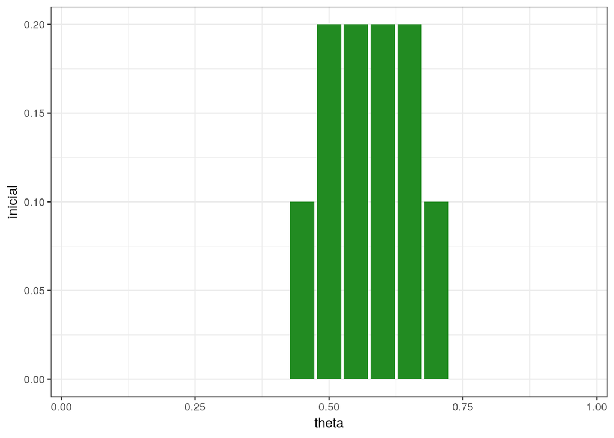

```r
ggplot(prior_df)+theme_bw()+
  geom_bar(aes(x=theta, y=prior), stat = "identity", fill="forestgreen")+
  ylab("inicial")
```

2. Usando tu inicial de a) grafica la posterior y decide si es creíble que las parejas que toman la medicina tienen una probabilidad de 0.5 de concebir un niño.

```r
# Estos son los nuevos datos que observo
N <- 50 # parejas
z <- 30 # niños

# Verosimilitud (viene de una Bernoulli)
Like    <- theta ^ z * (1 - theta) ^ (N - z)
product <- Like * prior
```

```r
# Distribución posterior (normalizamos)
post <- product / sum(product)

dists <- bind_cols(prior_df, post = post)
round(dists, 3)
```

```
## # A tibble: 19 x 3
##    theta prior  post
##    <dbl> <dbl> <dbl>
##  1  0.05   0   0
##  2  0.1    0   0
##  3  0.15   0   0
##  4  0.2    0   0
##  5  0.25   0   0
##  6  0.3    0   0
##  7  0.35   0   0
##  8  0.4    0   0
##  9  0.45   0.1 0.017
## 10  0.5    0.2 0.117
## 11  0.55   0.2 0.249
## 12  0.6    0.2 0.321
## 13  0.65   0.2 0.245
## 14  0.7    0.1 0.052
## 15  0.75   0   0
## 16  0.8    0   0
## 17  0.85   0   0
## 18  0.9    0   0
## 19  0.95   0   0
```

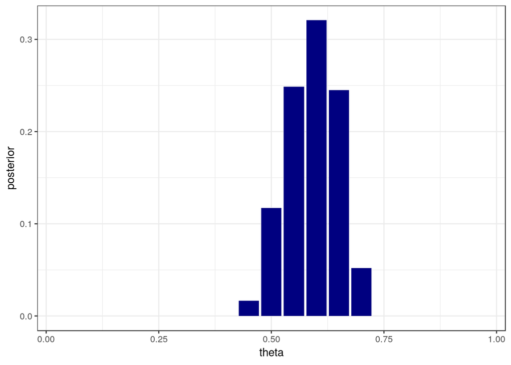

```r
ggplot(dists)+theme_bw()+
  geom_bar(aes(theta,post), stat = "identity", fill="navyblue")+
  ylab("posterior")
```

3. Supón que la farmacéutica asevera que la probabilidad de concebir un niño cuando se toma la medicina es cercana al 60% con alta certeza. Representa esta postura con una distribución inicial Beta(60,40). Comparala con la inicial de un escéptico que afirma que la medicina no hace diferencia, representa esta creencia con una inicial Beta(50,50). Recuerda que
   $$p(x)=Beta(z+a,N-z+b)/Beta(a,b)$$
   Calcula el valor de $p(x)$ para cada modelo y el factor de Bayes (asume $p(M_1)=p(M_2)=0.5$).

```r
px_M1  <- beta(z+60,N-z+40)/beta(60,40)
px_M2  <- beta(z+50,N-z+50)/beta(50,50)
Bayfac <- px_M1/px_M2
Bayfac
```

```
## [1] 1.95602
```

El factor de Bayes es 1.956, por lo que el modelo de la farmacéutica es más adecuado que el modelo escéptico.

2. **Otra familia conjugada** Supongamos que nos interesa analizar el IQ de una muestra de estudiantes del ITAM y suponemos que el IQ de un estudiante tiene una distribución normal $x \sim N(\theta, \sigma^2)$ con $\sigma ^ 2$ conocida.

Considera que observamos el IQ de un estudiante $x$. La verosimilitud del modelo es:
$$p(x|\theta)=\frac{1}{\sqrt{2\pi\sigma^2}}exp\left(-\frac{1}{2\sigma^2}(x-\theta)^2\right)$$

Realizaremos un análisis bayesiano por lo que hace falta establecer una distribución inicial, elegimos $p(\theta)$ que se distribuya $N(\mu, \tau^2)$ donde elegimos los parámetros $\mu, \tau$ que mejor describan nuestras creencias iniciales, por ejemplo si tengo mucha certeza de que el $IQ$ promedio se ubica en 150, elegiría $\mu=150$ y una desviación estándar chica por ejemplo $\tau = 5$. Entonces la distribución inicial es:

$$p(\theta)=\frac{1}{\sqrt{2\pi\tau^2}}exp\left(-\frac{1}{2\tau^2}(\theta-\mu)^2\right)$$

1. Calcula la distribución posterior $p(\theta|x) \propto p(x|\theta)p(\theta)$, usando la inicial y verosimilitud que definimos arriba. Una vez que realices la multiplicación debes identificar el núcleo de una distribución Normal, ¿cuáles son sus parámetros (media y varianza)?

$$\begin{equation}
\begin{aligned}
p(\theta|x) &\propto p(x|\theta)p(\theta)\\
p(\theta|x) &\propto \frac{1}{\sqrt{2\pi\sigma^2}}exp\left(-\frac{1}{2\sigma^2}(x-\theta)^2\right)\cdot \frac{1}{\sqrt{2\pi\tau^2}}exp\left(-\frac{1}{2\tau^2}(\theta-\mu)^2\right)\\
p(\theta|x) &\propto exp\left(-\frac{1}{2\sigma^2}(x-\theta)^2\right)\cdot exp\left(-\frac{1}{2\tau^2}(\theta-\mu)^2\right)\\
p(\theta|x) &\propto exp\left(-\frac{1}{2\sigma^2}(x-\theta)^2-\frac{1}{2\tau^2}(\theta-\mu)^2\right)\\
p(\theta|x) &\propto exp\left(-\frac{1}{2\sigma^2}(x^2-2\theta \cdot x +\theta^2)-\frac{1}{2\tau^2}(\theta^2-2\mu\theta +\mu^2)\right)\\
p(\theta|x) &\propto exp\left(-\frac{1}{2}\frac{\tau^2+\sigma^2}{\tau^2\sigma^2}\left(\theta-\frac{x\tau^2+\mu\sigma^2}{\tau^2+\sigma^2}\right)^2\right)\\
\end{aligned}
\end{equation}$$

Los parámetros de la normal son media: $\frac{x\tau^2+\mu\sigma^2}{\tau^2+\sigma^2}$ y la varianza es: $\frac{\tau^2\sigma^2}{\tau^2+\sigma^2}$.